# Assignment 3B Window Functions: Code Base

Lakeranie Boodram

2026-09-16

```r
# Install these only if you do not already have them
# install.packages("tidyquant")
# install.packages("dplyr")
# install.packages("lubridate")
# install.packages("ggplot2")

library(tidyquant)
library(dplyr)
library(lubridate)
library(ggplot2)
```

```r
stocks <- tq_get(
  c("AAPL", "MSFT"),
  from = "2022-01-01"
)

head(stocks)
```

```
## # A tibble: 6 × 8
##   symbol date        open  high   low close    volume adjusted
##   <chr>  <date>     <dbl> <dbl> <dbl> <dbl>     <dbl>    <dbl>
## 1 AAPL   2022-01-03  178.  183.  178.  182. 104487900     178.
## 2 AAPL   2022-01-04  183.  183.  179.  180.  99310400     176.
## 3 AAPL   2022-01-05  180.  180.  175.  175.  94537600     171.
## 4 AAPL   2022-01-06  173.  175.  172.  172   96904000     168.
## 5 AAPL   2022-01-07  173.  174.  171.  172.  86709100     168.
## 6 AAPL   2022-01-10  169.  172.  168.  172. 106765600     168.
```

```r
stock_data <- stocks %>%
  select(symbol, date, adjusted) %>%
  arrange(symbol, date) %>%
  mutate(year = year(date))

head(stock_data)
```

```
## # A tibble: 6 × 4
##   symbol date       adjusted  year
##   <chr>  <date>        <dbl> <dbl>
## 1 AAPL   2022-01-03     178.  2022
## 2 AAPL   2022-01-04     176.  2022
## 3 AAPL   2022-01-05     171.  2022
## 4 AAPL   2022-01-06     168.  2022
## 5 AAPL   2022-01-07     168.  2022
## 6 AAPL   2022-01-10     168.  2022
```

```r
stock_data <- stock_data %>%
  group_by(symbol, year) %>%
  mutate(
    ytd_average = cummean(adjusted)
  ) %>%
  ungroup()

head(stock_data, 10)
```

```
## # A tibble: 10 × 5
##    symbol date       adjusted  year ytd_average
##    <chr>  <date>        <dbl> <dbl>       <dbl>
##  1 AAPL   2022-01-03     178.  2022        178.
##  2 AAPL   2022-01-04     176.  2022        177.
##  3 AAPL   2022-01-05     171.  2022        175.
##  4 AAPL   2022-01-06     168.  2022        173.
##  5 AAPL   2022-01-07     168.  2022        172.
##  6 AAPL   2022-01-10     168.  2022        171.
##  7 AAPL   2022-01-11     171.  2022        171.
##  8 AAPL   2022-01-12     171.  2022        171.
##  9 AAPL   2022-01-13     168.  2022        171.
## 10 AAPL   2022-01-14     169.  2022        171.
```

```r
stock_data <- stock_data %>%
  group_by(symbol) %>%
  arrange(date, .by_group = TRUE) %>%
  mutate(
    cumulative_price = cumsum(adjusted),
    six_day_average = if_else(
      row_number() >= 6,
      (cumulative_price - lag(cumulative_price, 6, default = 0)) / 6,
      NA_real_
    )
  ) %>%
  ungroup()

head(stock_data, 10)
```

```
## # A tibble: 10 × 7
##    symbol date       adjusted  year ytd_average cumulative_price six_day_average
##    <chr>  <date>        <dbl> <dbl>       <dbl>            <dbl>           <dbl>
##  1 AAPL   2022-01-03     178.  2022        178.             178.             NA
##  2 AAPL   2022-01-04     176.  2022        177.             353.             NA
##  3 AAPL   2022-01-05     171.  2022        175.             524.             NA
##  4 AAPL   2022-01-06     168.  2022        173.             692.             NA
##  5 AAPL   2022-01-07     168.  2022        172.             860.             NA
##  6 AAPL   2022-01-10     168.  2022        171.            1029.            171.
##  7 AAPL   2022-01-11     171.  2022        171.            1200.            170.
##  8 AAPL   2022-01-12     171.  2022        171.            1371.            170.
##  9 AAPL   2022-01-13     168.  2022        171.            1539.            169.
## 10 AAPL   2022-01-14     169.  2022        171.            1708.            169.
```

```r
stock_results <- stock_data %>%
  select(
    symbol,
    date,
    adjusted,
    ytd_average,
    six_day_average
  )

head(stock_results, 20)
```

```
## # A tibble: 20 × 5
##    symbol date       adjusted ytd_average six_day_average
##    <chr>  <date>        <dbl>       <dbl>           <dbl>
##  1 AAPL   2022-01-03     178.        178.             NA
##  2 AAPL   2022-01-04     176.        177.             NA
##  3 AAPL   2022-01-05     171.        175.             NA
##  4 AAPL   2022-01-06     168.        173.             NA
##  5 AAPL   2022-01-07     168.        172.             NA
##  6 AAPL   2022-01-10     168.        171.            171.
##  7 AAPL   2022-01-11     171.        171.            170.
##  8 AAPL   2022-01-12     171.        171.            170.
##  9 AAPL   2022-01-13     168.        171.            169.
## 10 AAPL   2022-01-14     169.        171.            169.
## 11 AAPL   2022-01-18     166.        170.            169.
## 12 AAPL   2022-01-19     162.        170.            168.
## 13 AAPL   2022-01-20     161.        169.            166.
## 14 AAPL   2022-01-21     159.        168.            164.
## 15 AAPL   2022-01-24     158.        168.            162.
## 16 AAPL   2022-01-25     156.        167.            160.
## 17 AAPL   2022-01-26     156.        166.            159.
## 18 AAPL   2022-01-27     156.        166.            157.
## 19 AAPL   2022-01-28     166.        166.            158.
## 20 AAPL   2022-01-31     171.        166.            160.
```

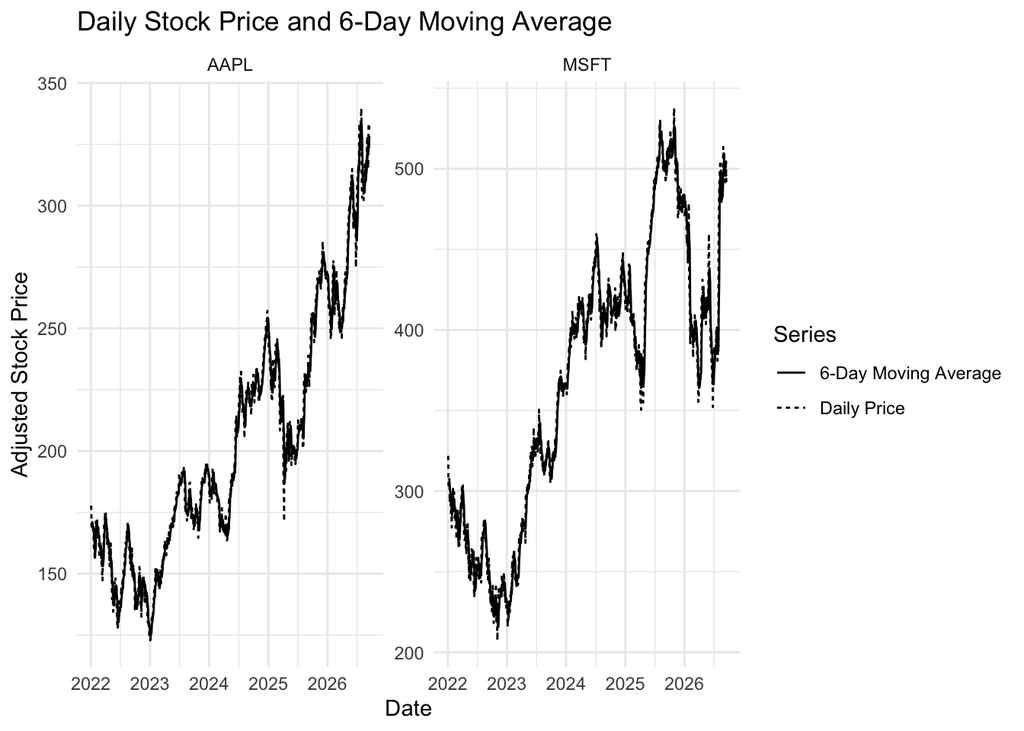

```r
ggplot(stock_results, aes(x = date)) +
  geom_line(aes(y = adjusted, linetype = "Daily Price")) +
  geom_line(aes(y = six_day_average,
                linetype = "6-Day Moving Average")) +
  facet_wrap(~ symbol, scales = "free_y") +
  labs(
    title = "Daily Stock Price and 6-Day Moving Average",
    x = "Date",
    y = "Adjusted Stock Price",
    linetype = "Series"
  ) +
  theme_minimal()
```

# Interpretation

The 6-day moving average follows the overall direction of the daily stock price while smoothing some of the short-term fluctuations. Since the moving average uses the current trading day and the previous five trading days, it changes more gradually than the daily adjusted price.

The results for Apple and Microsoft are calculated separately because the data is grouped by stock symbol. The first five observations for each stock do not have a 6-day moving average because there are not yet six trading days available for the calculation.

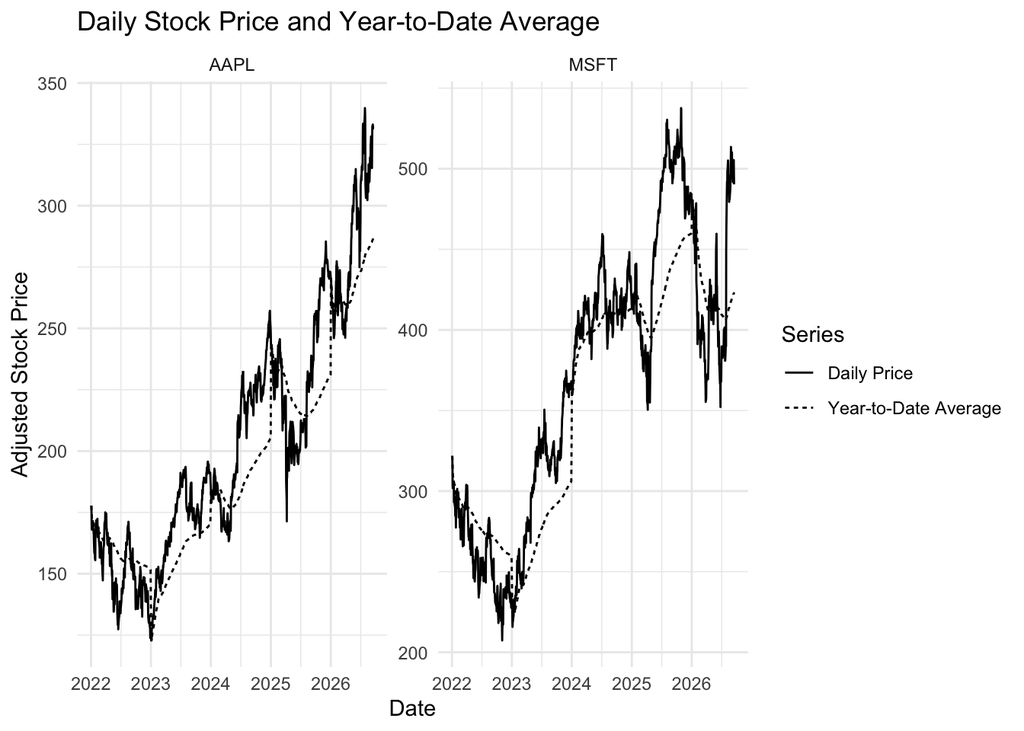

```r
ggplot(stock_results, aes(x = date)) +
  geom_line(aes(y = adjusted, linetype = "Daily Price")) +
  geom_line(aes(y = ytd_average,
                linetype = "Year-to-Date Average")) +
  facet_wrap(~ symbol, scales = "free_y") +
  labs(
    title = "Daily Stock Price and Year-to-Date Average",
    x = "Date",
    y = "Adjusted Stock Price",
    linetype = "Series"
  ) +
  theme_minimal()
```

# Year-to-Date Interpretation

The year-to-date average shows the average adjusted stock price from the beginning of each year through each trading day. Because the data is grouped by stock symbol and year, the calculation restarts at the beginning of every new year for both Apple and Microsoft.

Compared with the daily stock price, the year-to-date average changes more gradually because it includes all previous trading days within the same year.

# Sources

Yahoo Finance. Historical stock price data for Apple Inc. (AAPL) and Microsoft Corporation (MSFT). The stock price data used in this assignment was accessed through the `tidyquant` package. https://finance.yahoo.com/

Business Science. `tidyquant` documentation: `tq_get()` for retrieving stock prices and other financial data in R. https://business-science.github.io/tidyquant/reference/tq_get.html

Posit / tidyverse. `dplyr` Window Functions documentation. This resource was used for the year-to-date average and the 6-day moving average calculations using functions such as `cummean()`, `cumsum()`, `lag()`, and `row_number()`. https://dplyr.tidyverse.org/articles/window-functions.html

Posit / tidyverse. `dplyr` Grouped Data documentation. This resource was used for grouping the stock data by stock symbol and year. https://dplyr.tidyverse.org/articles/grouping.html

Posit / tidyverse. `lubridate` `year()` documentation. This function was used to extract the year from each stock price date. https://lubridate.tidyverse.org/reference/year.html

Posit / tidyverse. `ggplot2` `facet_wrap()` documentation. This resource was used to create separate Apple and Microsoft panels in the stock price graphs. https://ggplot2.tidyverse.org/reference/facet_wrap.html